# Graph Exploration - Correction Elements

Catherine Matias

October 2023

# Graph Friendship

```r
friends <- read.table(file='Friendship-network_data_2013.csv')
G <- graph_from_data_frame(friends, directed=TRUE)
V(G)
```

```
## + 134/134 vertices, named, from 7116c96:
##   [1] 1    3    27   28   32   34   45   46   48   55   61   63   70   72   79
##  [16] 80   85   92   101  117  119  120  122  124  125  132  134  147  151  156
##  [31] 159  165  170  173  184  190  196  200  201  202  205  211  213  214  219
##  [46] 222  232  240  242  245  248  252  255  257  265  268  272  275  277  285
##  [61] 312  325  327  335  343  353  364  366  388  407  425  429  440  441  447
##  [76] 452  465  468  471  480  486  488  491  492  494  496  498  502  520  531
##  [91] 545  564  576  577  587  601  603  605  612  622  624  634  642  674  691
## [106] 694  753  765  769  771  779  797  798  845  857  866  867  869  883  884
## [121] 894  920  959  960  970  974  1228 1332 1401 1485 1519 1594 1828 38
```

```r
E(G)
```

```
## + 668/668 edges from 7116c96 (vertex names):
##  [1] 1 ->55  1 ->205 1 ->272 1 ->494 1 ->779 1 ->894 3 ->1   3 ->28  3 ->147
## [10] 3 ->272 3 ->407 3 ->674 3 ->884 27->63  27->173 28->202 28->327 28->353
## [19] 28->407 28->429 28->441 28->492 28->545 32->440 32->624 32->797 32->920
## [28] 34->151 34->277 34->502 34->866 45->48  45->79  45->335 45->496 45->601
## [37] 45->674 45->765 46->117 46->196 46->257 46->268 48->45  48->79  48->496
## [46] 55->1   55->170 55->205 55->252 55->272 55->779 55->883 55->894 61->797
## [55] 63->27  63->125 63->173 70->101 70->132 70->240 70->425 70->447 72->407
## [64] 72->674 72->857 79->45  79->48  79->335 79->496 79->601 79->674 79->765
## [73] 80->120 80->285 80->468 80->601 85->190 85->213 85->214 85->335 85->603
## [82] 85->605 85->765 92->468 92->845
## + ... omitted several edges
```

```r
is.directed(G)
```

```
## [1] TRUE
```

We have a graph of 134 nodes and 668 directed edges. Nodes have attributes which are names:

```r
vertex_attr(G)
```

```
## $name
##   [1] "1"    "3"    "27"   "28"   "32"   "34"   "45"   "46"   "48"   "55"
##  [11] "61"   "63"   "70"   "72"   "79"   "80"   "85"   "92"   "101"  "117"
##  [21] "119"  "120"  "122"  "124"  "125"  "132"  "134"  "147"  "151"  "156"
##  [31] "159"  "165"  "170"  "173"  "184"  "190"  "196"  "200"  "201"  "202"
##  [41] "205"  "211"  "213"  "214"  "219"  "222"  "232"  "240"  "242"  "245"
##  [51] "248"  "252"  "255"  "257"  "265"  "268"  "272"  "275"  "277"  "285"
##  [61] "312"  "325"  "327"  "335"  "343"  "353"  "364"  "366"  "388"  "407"
##  [71] "425"  "429"  "440"  "441"  "447"  "452"  "465"  "468"  "471"  "480"
##  [81] "486"  "488"  "491"  "492"  "494"  "496"  "498"  "502"  "520"  "531"
##  [91] "545"  "564"  "576"  "577"  "587"  "601"  "603"  "605"  "612"  "622"
## [101] "624"  "634"  "642"  "674"  "691"  "694"  "753"  "765"  "769"  "771"
## [111] "779"  "797"  "798"  "845"  "857"  "866"  "867"  "869"  "883"  "884"
## [121] "894"  "920"  "959"  "960"  "970"  "974"  "1228" "1332" "1401" "1485"
## [131] "1519" "1594" "1828" "38"
```

Let’s display the sequence of incoming degrees of the graph

```r
degree(G,mode="in")
```

```
##    1    3   27   28   32   34   45   46   48   55   61   63   70   72   79   80
##   11    4    3   10    2    4    8    5    5    9    0    2    5    4    8    5
##   85   92  101  117  119  120  122  124  125  132  134  147  151  156  159  165
##    5    3    8   11    8    4    6    2    7    6    4    3    5    0    0    1
##  170  173  184  190  196  200  201  202  205  211  213  214  219  222  232  240
##    8    2    5    4    6    4    4    3   11    3    3    5    4    3    2    6
##  242  245  248  252  255  257  265  268  272  275  277  285  312  325  327  335
##    3    9    2    7    2    4    7    5   15    3    3    4    2    6    6    6
##  343  353  364  366  388  407  425  429  440  441  447  452  465  468  471  480
##    4    6    6    1    5   12    8    5    3    8    9    8    4    6    2    2
##  486  488  491  492  494  496  498  502  520  531  545  564  576  577  587  601
##    2    3    4    6    8    7    2    6    3    3    3    3    3    2    7    4
##  603  605  612  622  624  634  642  674  691  694  753  765  769  771  779  797
##    5    7    2    7    7    9    8    6   13    5    4    6    4    1    9   10
##  798  845  857  866  867  869  883  884  894  920  959  960  970  974 1228 1332
##    4    5    3    5    2   10   12    3    9    2    5    5    2    2    2    7
## 1401 1485 1519 1594 1828   38
##    4    1    5    2    2    3
```

You notice that each node appears with its name and its degree. We can draw a barplot of this distribution

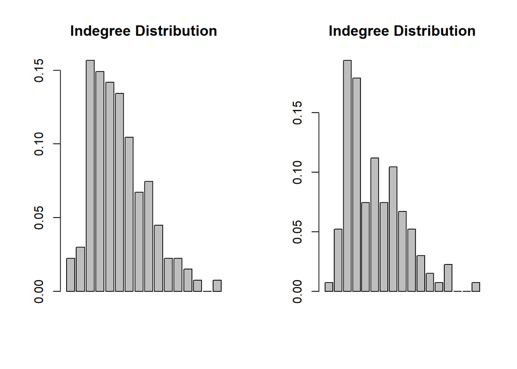

```r
par(mfrow=c(1,2))
barplot(degree_distribution(G,mode="in"),main="Indegree Distribution")
barplot(degree_distribution(G,mode="out"),main="Indegree Distribution")
```

Note that by default we do not have the x-coordinates. You should know that `degree_distribution` starts by listing the nodes of degree 0 (isolated).

By hand :

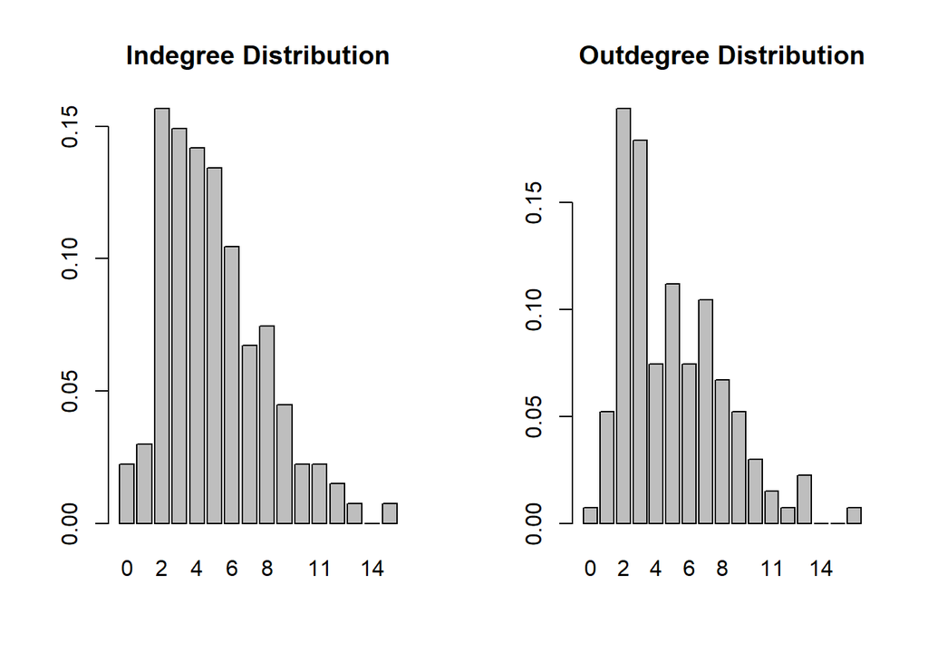

```r
par(mfrow=c(1,2))
barplot(degree_distribution(G,mode="in"),names.arg=as.character(0:max(degree(G,mode="in"))), main="Indegree Distribution")
barplot(degree_distribution(G,mode="out"),names.arg=as.character(0:max(degree(G,mode="out"))), main="Outdegree Distribution")
```

Or again by hand (in counts rather than frequencies; and zero counts are ignored)

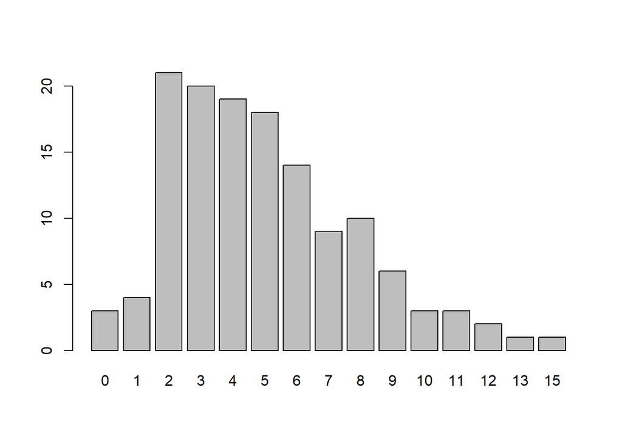

```r
barplot(table(degree(G,mode="in")))
```

Much more elegant, with `ggplot2`:

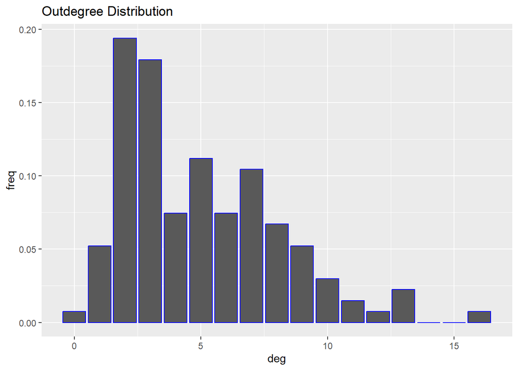

```r
degree.df <- data.frame(deg=0:max(degree(G,mode="out")), freq=degree_distribution(G,mode="out"))
p <- ggplot(degree.df, aes(x=deg, y=freq)) + geom_bar(stat="identity",color="blue")
p + ggtitle("Outdegree Distribution")
```

Let’s study the connected components of G:

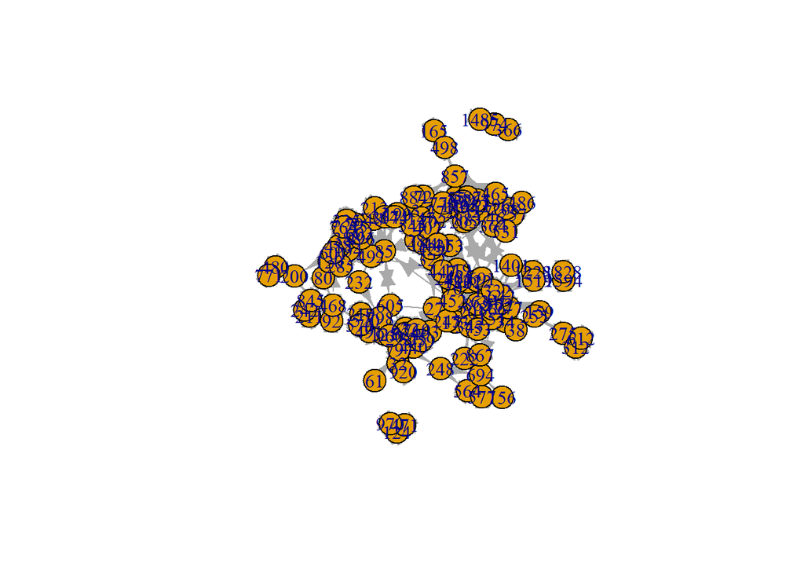

```r
plot(G)
```

```r
components(G)
```

```
## $membership
##    1    3   27   28   32   34   45   46   48   55   61   63   70   72   79   80
##    1    1    1    1    1    1    1    1    1    1    1    1    1    1    1    1
##   85   92  101  117  119  120  122  124  125  132  134  147  151  156  159  165
##    1    1    1    1    1    1    1    2    1    1    1    1    1    1    1    1
##  170  173  184  190  196  200  201  202  205  211  213  214  219  222  232  240
##    1    1    1    1    1    1    1    1    1    1    1    1    1    1    1    1
##  242  245  248  252  255  257  265  268  272  275  277  285  312  325  327  335
##    1    1    1    1    1    1    1    1    1    1    1    1    1    1    1    1
##  343  353  364  366  388  407  425  429  440  441  447  452  465  468  471  480
##    1    1    1    3    1    1    1    1    1    1    1    1    1    1    2    1
##  486  488  491  492  494  496  498  502  520  531  545  564  576  577  587  601
##    1    1    1    1    1    1    1    1    1    1    1    1    1    1    1    1
##  603  605  612  622  624  634  642  674  691  694  753  765  769  771  779  797
##    1    1    1    1    1    1    1    1    1    1    1    1    1    1    1    1
##  798  845  857  866  867  869  883  884  894  920  959  960  970  974 1228 1332
##    1    1    1    1    1    1    1    1    1    1    1    1    2    3    1    1
## 1401 1485 1519 1594 1828   38
##    1    3    1    1    1    1
##
## $csize
## [1] 128   3   3
##
## $no
## [1] 3
```

This graph has 3 connected components (cc), of respective sizes 128, 3 and 3. The second connected component contains the nodes “124”, “471” and “970”. The density and diameter of the graph are

```r
edge_density(G)
```

```
## [1] 0.03748176
```

```r
diameter(G, directed=TRUE, unconnected=FALSE)
```

```
## [1] Inf
```

```r
diameter(G, directed=TRUE, unconnected=TRUE)
```

```
## [1] 12
```

The density of the graph is approximately 3.7% The diameter, calculated over the entire graph, is infinite (since there are multiple ccs). With the `unconnected=TRUE` option we obtain the maximum value of the diameter calculated on each component. To see the longest (directed) path in the graph (or one of the longest if there are several):

```r
get_diameter(G, directed=TRUE)
```

```
## + 13/134 vertices, named, from 7116c96:
##  [1] 248 222 343 101 240 327 407 674 45  601 200 480 771
```

Beware: by default, `diameter` computes the weighted longest shortest path. Example

```r
library(igraphdata)
data(karate)
diameter(karate)
```

```
## This graph was created by an old(er) igraph version.
##   Call upgrade_graph() on it to use with the current igraph version
##   For now we convert it on the fly...
```

```
## [1] 13
```

```r
get_diameter(karate)
```

```
## + 6/34 vertices, named, from 4b458a1:
## [1] Actor 16 John A   Actor 20 Mr Hi    Actor 6  Actor 17
```

```r
is.weighted(karate)
```

```
## [1] TRUE
```

We can calculate, at each node of the graph, the number of (undirected) triangles to which it belongs

```r
count_triangles(G)
```

```
##   [1] 33 11  1 16  4  8 13  5  3 25  0  1 10  3 13  3  8  2 19 39 16  4 11  1 15
##  [26] 18  4 16 33  0  0  0 25  1  7  4  9  1 16  4 42  3  3  5  6  1  1 15  3 12
##  [51]  1 14  0  5 22  8 45  1 12  5  1 17 14 10  2  9  7  0 18 26 21 13  3 10 19
##  [76] 21  1  7  1  1  1  3  7  7 25 10  0 16  6  1  3  2  6  1 20  6  9  6  1 21
## [101] 26 23 21  6 33  2  3 10 22  1 25 18  3  5  1 26  1 28 48  5 41  3 13  8  1
## [126]  0  3  7  4  0  5  1  1  1
```

The clustering coefficient is defined locally as the connection frequency between the neighbors of a node.

```r
transitivity(G,type="local") # Clustering coefficient
```

```
##   [1] 0.6000000 0.5238095 0.3333333 0.3555556 0.6666667 0.8000000 0.4642857
##   [8] 0.5000000 0.3000000 0.6944444       NaN 0.3333333 1.0000000 0.5000000
##  [15] 0.4642857 0.3000000 0.2222222 0.6666667 0.5277778 0.3250000 0.5714286
##  [22] 0.6666667 0.5238095 1.0000000 0.2727273 0.8571429 0.6666667 0.3555556
##  [29] 0.4230769       NaN 0.0000000       NaN 0.6944444 0.3333333 0.7000000
##  [36] 0.6666667 0.6000000 0.1666667 0.3555556 0.4000000 0.6363636 1.0000000
##  [43] 1.0000000 0.5000000 1.0000000 0.3333333 0.3333333 0.7142857 1.0000000
##  [50] 0.2666667 0.1666667 0.5000000 0.0000000 0.8333333 0.6111111 0.8000000
##  [57] 0.3308824 0.3333333 0.8000000 0.5000000 1.0000000 0.8095238 0.3888889
##  [64] 0.6666667 0.3333333 0.3214286 0.4666667       NaN 0.5000000 0.2857143
##  [71] 0.4666667 0.6190476 0.3000000 0.3571429 0.5277778 0.3818182 0.1666667
##  [78] 0.3333333 1.0000000 1.0000000 1.0000000 0.5000000 0.4666667 0.1944444
##  [85] 0.8928571 0.3571429 0.0000000 0.7619048 1.0000000 0.3333333 1.0000000
##  [92] 0.6666667 1.0000000 1.0000000 0.9523810 0.2142857 0.4285714 0.2142857
##  [99] 1.0000000 0.5833333 0.3939394 0.6388889 0.3818182 0.4000000 0.3626374
## [106] 0.2000000 0.5000000 0.6666667 0.6111111 1.0000000 0.5555556 0.4000000
## [113] 0.3000000 0.3333333 0.1000000 0.5777778 1.0000000 0.6222222 0.4571429
## [120] 0.8333333 0.7454545 1.0000000 0.8666667 0.8000000 1.0000000 0.0000000
## [127] 1.0000000 0.3333333 0.4000000       NaN 0.3333333 1.0000000 1.0000000
## [134] 0.3333333
```

There are NaN values for nodes that do not have at least two neighbors.

```r
for (v in V(G)[is.nan(transitivity(G,type="local"))]){
  print(paste0("Le noeud ",v, " a pour degré ", degree(G,mode="total")[v], " et intervient dans ",count_triangles(G)[v] , " triangles"))
}
```

```
## [1] "Le noeud 11 a pour degré 1 et intervient dans 0 triangles"
## [1] "Le noeud 30 a pour degré 1 et intervient dans 0 triangles"
## [1] "Le noeud 32 a pour degré 2 et intervient dans 0 triangles"
## [1] "Le noeud 68 a pour degré 2 et intervient dans 0 triangles"
## [1] "Le noeud 130 a pour degré 2 et intervient dans 0 triangles"
```

Interestingly, there are 3 nodes which have degree 2 and clustering coefficient NaN. Do you understand why? Hint: Look at which edges include a particular node

```r
neighbors(G, 32, mode='all')
```

```
## + 2/134 vertices, named, from 7116c96:
## [1] 498 498
```

```r
E(G)[.inc(32)]
```

```
## + 2/668 edges from 7116c96 (vertex names):
## [1] 165->498 498->165
```

The clustering coefficient is the average of the local coefficient

```r
mean(transitivity(G,type="local"),na.rm=TRUE)
```

```
## [1] 0.5591281
```

And the transitivity coefficient (default, `type="global"`)

```r
transitivity(G)
```

```
## [1] 0.4754041
```

We can see the neighbors of a particular node

```r
neighbors(G, 4,  mode='out')
```

```
## + 8/134 vertices, named, from 7116c96:
## [1] 202 327 353 407 429 441 492 545
```

```r
neighbors(G, 4, mode='in')
```

```
## + 10/134 vertices, named, from 7116c96:
##  [1] 3   147 202 327 353 407 429 441 492 545
```

```r
neighbors(G, 4, mode='all')
```

```
## + 18/134 vertices, named, from 7116c96:
##  [1] 3   147 202 202 327 327 353 353 407 407 429 429 441 441 492 492 545 545
```

By calculating the cliques of size 3, we find that there are 451 triangles in G:

```r
K3 <- cliques(G, min=3, max=3)
K3[[1]]
```

```
## + 3/134 vertices, named, from 7116c96:
## [1] 265 883 894
```

```r
length(K3)
```

```
## [1] 451
```

```r
sum(count_triangles(G))/3
```

```
## [1] 451
```

Centrality only makes sense for connected graphs. We therefore focus on the largest connected component of the graph (for the record, it was number 1, of size 128).

```r
G1 <- induced_subgraph(G,V(G)[components(G)$membership==1])
V(G1)
```

```
## + 128/128 vertices, named, from 723acb6:
##   [1] 1    3    27   28   32   34   45   46   48   55   61   63   70   72   79
##  [16] 80   85   92   101  117  119  120  122  125  132  134  147  151  156  159
##  [31] 165  170  173  184  190  196  200  201  202  205  211  213  214  219  222
##  [46] 232  240  242  245  248  252  255  257  265  268  272  275  277  285  312
##  [61] 325  327  335  343  353  364  388  407  425  429  440  441  447  452  465
##  [76] 468  480  486  488  491  492  494  496  498  502  520  531  545  564  576
##  [91] 577  587  601  603  605  612  622  624  634  642  674  691  694  753  765
## [106] 769  771  779  797  798  845  857  866  867  869  883  884  894  920  959
## [121] 960  1228 1332 1401 1519 1594 1828 38
```

We calculate the closeness centrality. Be careful as the graph is directed, taking into account (or not) the direction changes the result.

```r
closeness(G1,mode="total")
```

```
##           1           3          27          28          32          34
## 0.002298851 0.002169197 0.002118644 0.002309469 0.001779359 0.001798561
##          45          46          48          55          61          63
## 0.002159827 0.002008032 0.002155172 0.002222222 0.001552795 0.002061856
##          70          72          79          80          85          92
## 0.001788909 0.001945525 0.002159827 0.001904762 0.002487562 0.001814882
##         101         117         119         120         122         125
## 0.002016129 0.002392344 0.001915709 0.001941748 0.001869159 0.002164502
##         132         134         147         151         156         159
## 0.001811594 0.002092050 0.002267574 0.002237136 0.001584786 0.001730104
##         165         170         173         184         190         196
## 0.001305483 0.002212389 0.002049180 0.001953125 0.002293578 0.001937984
##         200         201         202         205         211         213
## 0.001715266 0.002237136 0.002262443 0.002475248 0.001620746 0.002040816
##         214         219         222         232         240         242
## 0.002358491 0.001818182 0.001865672 0.002083333 0.001897533 0.001620746
##         245         248         252         255         257         265
## 0.002183406 0.002012072 0.002288330 0.001526718 0.001908397 0.002070393
##         268         272         275         277         285         312
## 0.001912046 0.002538071 0.001287001 0.001972387 0.002012072 0.001108647
##         325         327         335         343         353         364
## 0.002066116 0.002197802 0.002127660 0.001893939 0.002109705 0.002036660
##         388         407         425         429         440         441
## 0.002141328 0.002320186 0.002049180 0.002032520 0.001980198 0.002267574
##         447         452         465         468         480         486
## 0.002155172 0.002475248 0.002053388 0.002016129 0.001412429 0.001788909
##         488         491         492         494         496         498
## 0.001972387 0.001984127 0.002314815 0.002169197 0.002352941 0.001562500
##         502         520         531         545         564         576
## 0.002008032 0.001818182 0.002049180 0.002000000 0.001757469 0.001818182
##         577         587         601         603         605         612
## 0.001587302 0.002164502 0.002145923 0.002277904 0.002237136 0.001108647
##         622         624         634         642         674         691
## 0.002217295 0.002257336 0.002212389 0.002202643 0.002079002 0.002518892
##         694         753         765         769         771         779
## 0.001980198 0.001855288 0.002127660 0.002159827 0.001412429 0.002341920
##         797         798         845         857         866         867
## 0.001930502 0.002079002 0.001703578 0.001937984 0.002169197 0.001672241
##         869         883         884         894         920         959
## 0.002237136 0.002544529 0.002049180 0.002237136 0.001694915 0.001923077
##         960        1228        1332        1401        1519        1594
## 0.001960784 0.001908397 0.002207506 0.002164502 0.001941748 0.001562500
##        1828          38
## 0.001562500 0.001795332
```

```r
closeness(G1)
```

```
##           1           3          27          28          32          34
## 0.002008032 0.002127660 0.001584786 0.002197802 0.001644737 0.001579779
##          45          46          48          55          61          63
## 0.001953125 0.001818182 0.001730104 0.002044990 0.001434720 0.001776199
##          70          72          79          80          85          92
## 0.001658375 0.001904762 0.001953125 0.001848429 0.001930502 0.001555210
##         101         117         119         120         122         125
## 0.001834862 0.002325581 0.001672241 0.001663894 0.001628664 0.001976285
##         132         134         147         151         156         159
## 0.001675042 0.001834862 0.002257336 0.001949318 0.200000000 0.001552795
##         165         170         173         184         190         196
## 0.001293661 0.001904762 0.001782531 0.001841621 0.001915709 0.001834862
##         200         201         202         205         211         213
## 0.001383126 0.001941748 0.002145923 0.002314815 0.001557632 0.001579779
##         214         219         222         232         240         242
## 0.001650165 0.001517451 0.001298701 0.001937984 0.001845018 0.001557632
##         245         248         252         255         257         265
## 0.002040816 0.001127396 0.001964637 0.200000000 0.001503759 0.002000000
##         268         272         275         277         285         312
## 0.001821494 0.002272727 0.333333333 0.001828154 0.001941748 0.250000000
##         325         327         335         343         353         364
## 0.001926782 0.002173913 0.001579779 0.001524390 0.002044990 0.001834862
##         388         407         425         429         440         441
## 0.001908397 0.002192982 0.001949318 0.002036660 0.001845018 0.002227171
##         447         452         465         468         480         486
## 0.001915709 0.001976285 0.001748252 0.001908397 0.001184834 0.001579779
##         488         491         492         494         496         498
## 0.001633987 0.001526718 0.002169197 0.002070393 0.002049180 0.001538462
##         502         520         531         545         564         576
## 0.001824818 0.001526718 0.001805054 0.001926782 0.500000000 0.001526718
##         577         587         601         603         605         612
## 0.500000000 0.001960784 0.001886792 0.001818182 0.001865672 0.250000000
##         622         624         634         642         674         691
## 0.001972387 0.002008032 0.001785714 0.001919386 0.002004008 0.002252252
##         694         753         765         769         771         779
## 0.500000000 0.001666667 0.001579779 0.001988072 0.001184834 0.002150538
##         797         798         845         857         866         867
## 0.001748252 0.001620746 0.001655629 0.001890359 0.001926782 0.001291990
##         869         883         884         894         920         959
## 0.001904762 0.002207506 0.001901141 0.002132196 0.001612903 0.001792115
##         960        1228        1332        1401        1519        1594
## 0.001607717 0.001592357 0.001890359 0.001594896 0.001600000 0.001338688
##        1828          38
## 0.001338688         NaN
```

For betweenness centrality

```r
betweenness(G1)
```

```
##           1           3          27          28          32          34
##  103.416605  155.859112  572.218972  893.607273    4.589560   49.942912
##          45          46          48          55          61          63
##  651.528188  156.076462  340.176810  131.927802    0.000000  393.477752
##          70          72          79          80          85          92
##    0.000000  382.564123  651.528188  672.398653 1537.614248   47.308111
##         101         117         119         120         122         125
##  863.095996 1852.001478   53.540476   80.022171  477.850618 1835.859775
##         132         134         147         151         156         159
##    2.935714   50.477482  168.513270  311.597806    0.000000    0.000000
##         165         170         173         184         190         196
##    0.000000   38.257272  152.298002    3.332937  591.266090    8.846281
##         200         201         202         205         211         213
##  561.985243  904.267741  235.708636 1769.428930    0.000000    0.000000
##         214         219         222         232         240         242
##  141.479678    0.000000  428.562564  166.374197  228.774206    0.000000
##         245         248         252         255         257         265
## 1756.232039  464.587537  164.971449  357.000000    1.942976   41.175188
##         268         272         275         277         285         312
##   38.558828 1915.407122  242.000000   23.672103  448.538288    0.000000
##         325         327         335         343         353         364
##  677.446577  807.435939  146.865050  690.352094  562.560791  475.864148
##         388         407         425         429         440         441
##  253.959597 1669.997366  441.009924   60.760632  390.223861 1401.794460
##         447         452         465         468         480         486
## 1006.073405  919.193258  405.281584 1340.094879  117.000000    0.000000
##         488         491         492         494         496         498
##   13.491545  140.926738 1490.723527   38.972282  615.056791  240.000000
##         502         520         531         545         564         576
##  262.085998   15.690536  383.798841    0.000000   27.800816   15.690536
##         577         587         601         603         605         612
##    0.000000   22.849255 1015.567051  498.787583 1379.327341    0.000000
##         622         624         634         642         674         691
##  344.478796  402.714683   17.761737  864.939718  871.633432 3431.653962
##         694         753         765         769         771         779
##  148.649184   34.560006  146.865050   33.417097    0.000000  463.855920
##         797         798         845         857         866         867
##  236.156412  176.641230  479.638045  709.240169   77.665735    0.000000
##         869         883         884         894         920         959
##  182.698195 1475.755257    5.623074   47.988978    0.000000  180.661827
##         960        1228        1332        1401        1519        1594
##   58.884094    0.000000  660.760018  466.310089  505.968026    0.000000
##        1828          38
##    0.000000    0.000000
```

[figure not shown]

```r
plot(G, vertex.size=betweenness(G))
```

To count motifs or patterns, we can use `count_subgraph_isomorphisms`. Here we will first remove the directions (but we can look for a directed motif too)

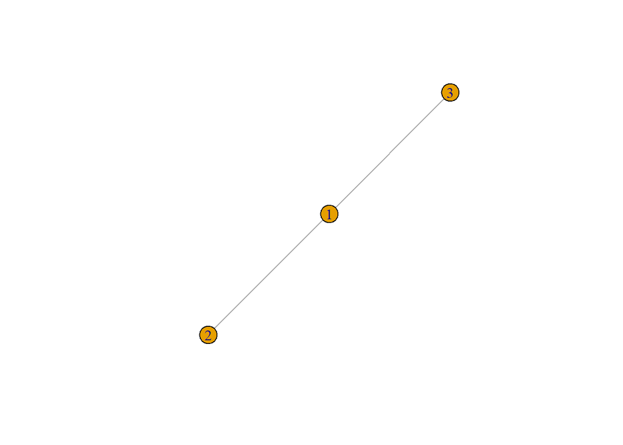

```r
Two.star <- make_star(3,mode="undirected")
Three.star <- make_star(4,mode="undirected")
plot(Two.star)
```

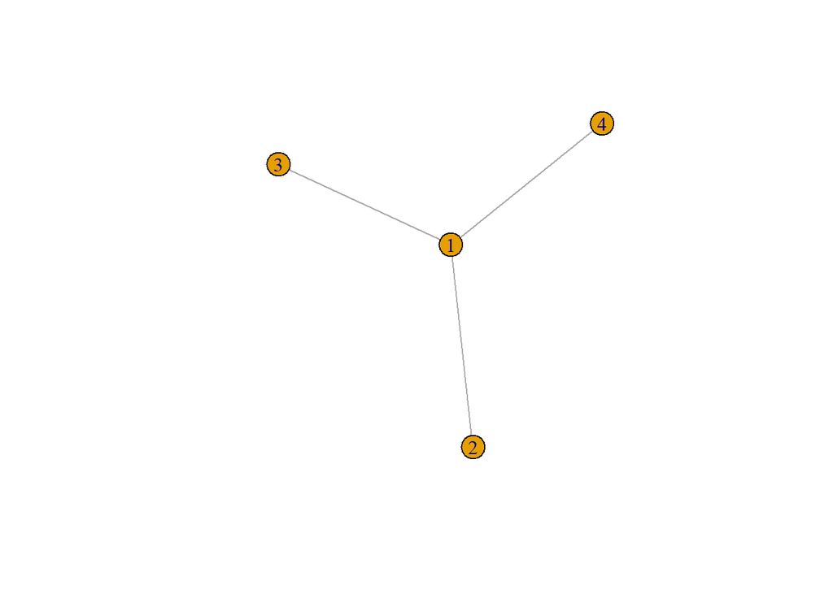

```r
plot(Three.star)
```

```r
G_undirected <- as.undirected(G)
count_subgraph_isomorphisms(Two.star,G_undirected)
```

```
## [1] 5692
```

```r
count_subgraph_isomorphisms(Three.star,G_undirected)
```

```
## [1] 44682
```

```r
# with a directed motif
Two.stard <- make_star(3)
count_subgraph_isomorphisms(Two.stard,G)
```

```
## [1] 3770
```

Finally, to count all the small patterns up to a fixed number of nodes `size’ (by default it is 3) we can use

```r
motifs(G_undirected)
```

```
## [1]   NA   NA 1493  451
```

There are 4 different undirected patterns on 3 nodes: - the empty pattern of order 3 - a single edge on 3 nodes - the “V” pattern ie the ‘Two.star’ pattern above - the triangle.

When we calculate the ‘patterns’ function on a graph (and ‘size’=3 by default), we therefore obtain 4 values. The first two values (which correspond to the empty pattern of order 3 and to a single edge on 3 nodes respectively) are worth NA. This is because if the pattern is not connected, then the answer of this function is NA.

Then, the function counts the number of induced “V” patterns (ie the ‘Two.star’ pattern above). Please note, this is not the number of connected triples, because a triangle does not count as a ‘Two.star’ (there is one edge too many). Finally, the last value is the number of triangles.